# CAPÍTULO 1: Introducción al análisis espacial utilizando R

## Instalación de R, y del R Studio

**R**, también conocido como “GNU S”, es un entorno y un lenguaje para el cálculo estadístico y la generación de gráficos. R implementa un dialecto del premiado lenguaje S, desarrollado en los Laboratorios Bell por John Chambers et al

Para los no iniciados diremos que R provee un acceso relativamente sencillo a una amplia variedad de técnicas estadísticas y graficas. Para los usuarios avanzados se ofrece un lenguaje de programación completo con el que añadir nuevas técnicas mediante la definición de funciones. “S ha modificado para siempre la forma en la que las personas analizan, visualizan y manipulan los datos” (Association of Computer Machinery Software System Award 1998 a John Chambers).

Actualmente, S y R son los dos lenguajes más utilizados en investigación en estadística.

Los grandes atractivos de R/S son:

- La capacidad de combinar, sin fisuras, análisis “preempaquetados” (ej., una regresión logística) con análisis ad-hoc, específicos para una situación: capacidad de manipular y modificar datos y funciones.
- Los gráficos de alta calidad: visualización de datos y producción de gráficos para papers.
- La comunidad de R es muy dinámica, con gran crecimiento del número de paquetes, e integrada por estadísticos de gran renombre (ej., J. Chambers, L. Terney, B. Ripley, D. Bates, etc.).
- Hay extensiones específicas a nuevas ´áreas como bioinformática, geoestadística y modelos gráficos.
- Es un lenguaje orientado a objetos.

### Obtención e instalación de R / Rstudio

Depende del sistema operativo, pero todo se puede encontrar en:

- http://cran.es.r-project.org/bin

**Windows:** se puede obtener un ejecutable desde http://cran.es.r-project.org/bin/windows/base por ejemplo la versión de 32 bits R-2.4.1-win32.exe

Al ejecutar el archivo se instalará el sistema base y los paquetes recomendados.

**GNU/Linux:** (dos opciones)

1. Obtener el R-x.y.z.tar.gz y compilar desde las fuentes. También bajar los paquetes adicionales e instalarlos. (Buena forma de comprobar que el sistema tiene development tools).
2. Obtener binarios (ej., *.deb para Debian, *.rpm para RedHat, SuSE, Mandrake)

### RSTUDIO

Es una poderosa herramienta de desarrollo integrado un ambiente de desarrollo integrado, donde se puede desarrollar los diferentes proyectos que se aborden utilizando el leguaje R.

Se puede descargar la última versión del programa desde:

https://www.rstudio.com/

#### Ambiente de Desarrollo

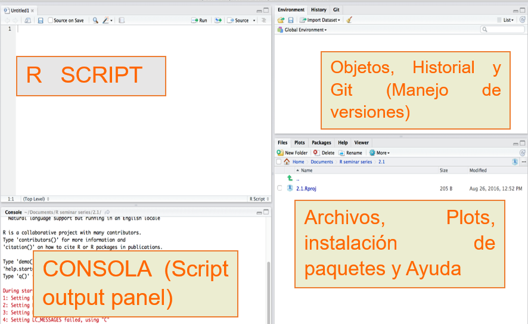

## Introducción a la programación

### Hola Mundo

**R** Utilizamos la función *print()* para desplegar información en la pantalla

```r
##Hola Mundo
print("Hola Mundo")
```

```
## [1] "Hola Mundo"
```

```r
print(paste('Hola,', 'como', 'estas?'))
```

```
## [1] "Hola, como estas?"
```